# Demultiplexing of ddRAD sequence data

Mar Llaberia and José Ignacio Lucas Lledó

2025-02-25

# Introduction

The goal of the assembly process is to convert raw or sorted `fastq` data into assembled loci that can be formatted for downstream analyses in phylogenetic or population genetic inference software. `ipyrad` offers an atomized process of sequential steps to create a modular workflow. `ipyrad` works in bash command line, and needs an input file (*demux* format, i.e. .txt) with all the analysis information you want to carry out. It is very easy to use, as it has a straightforward procedure with only 7 steps that you can execute all in one, or one by one (as we do here). Anyways, we need to create these input file and specify the parameters needed for a given assembly. `ipyrad` will automatically create this file with the argument `-n`, and we only need to modify the parameters. Manual of `ipyrad`: https://ipyrad.readthedocs.io/en/latest/6-params.html

The *params* file lists in each line one parameter, followed by a ## mark, the name of the parameter, and then a short description of its purpose. Note: not all the parameters are needed in all steps. The ideal is that you modify all the parameters at the same time, and then, execute all steps together. But, as we only need for now the first and (maybe) the second steps (demultiplex and filtering), we will only modify the steps that we need.

In our case, we have many libraries with multiple lanes of sequencing for the samples (samples of different species, important point later). To begin with the assembly process, we have to demultiplex the barcodes and join the multiple lanes of sequence data that belong to the same samples. To do that, first we need to create a directory (a folder where all the outputs will be saved) and the input file for every fastq.gz and barcode file. /*/ Don’t move or rename directories that ipyrad creates or your assembly will break.

`ipyrad` works efficiently in the sense that, if you have `_R1_` and `_R2_` in the names of the `fastq.gz` files, it automatically detects that there are forward and reverse reads, and you don’t need to specify both files in the command line. Additionally, `ipyrad` detects if one sample have been sequenced several times, and join the separated sequences in one.

## Demultiplex the raw data files

### Change the large name of files

Before execute the Step 1, I’m going to change the names of the raw data. I’m going to create symbolic links to the original file. That is to say, basically create a “direct access” to the raw data but with the name that interests us. Why am I doing this? In short, because the original file names for the forward and reverse reads (R1 and R2) of the same library didn’t match. This represents a serious problem since if the names of these files are not exactly the same (except for R1 and R2) `ipyrad` does not identify them as part of the same run and therefore, only demultiplexes the forward read. By creating symbolic links, we only modify the names of the “shortcuts” to match without damaging the original data.

Additionally to the symbolic links, I’m going to take advantage of this step and modify the name of libraries to join later the sequences of the same sample present in the two libraries. The thing here is, since library PAR3 is a “replicate” of library PAR2, the barcodes used in PAR3 are the same as in PAR2. So, the barcode files to demultiplex both libraries are the same. This being the case, I change the name of PAR3 to PAR2 in the symbolic links. This way, later in step 1, `ipyrad` will “understand” that there is an individual with two sequences files, and then merge them in one single file.

```bash
# PATHS TO RAW DATA AND working DIRECTORY
FASTQDIR1=/gata/joiglu/cophyhopa/data/PARASIT_HiSeq_data_WINDU311
FASTQDIR2=/gata/joiglu/cophyhopa/data/PARASIT_HiSeq_data_WINDU313
FASTQDIR3=/gata/joiglu/cophyhopa/data/PARASIT_HiSeq_data_WINDU341

DATADIR=../../data

## Showing the problem: the series of character at the end of the name

# ls -1 /gata/joiglu/cophyhopa/data/PARASIT_HiSeq_data_WINDU313/*.fastq.gz | head -n 5
# /gata/joiglu/cophyhopa/data/PARASIT_HiSeq_data_WINDU313/PAR1no1_L7_R1_001_Qk4GYcUUzWUV.fastq.gz
# /gata/joiglu/cophyhopa/data/PARASIT_HiSeq_data_WINDU313/PAR1no1_L7_R2_001_dHNcyERk0FTR.fastq.gz
# /gata/joiglu/cophyhopa/data/PARASIT_HiSeq_data_WINDU313/PAR1no2_L7_R1_001_2Xdb5mLfoS8J.fastq.gz
# /gata/joiglu/cophyhopa/data/PARASIT_HiSeq_data_WINDU313/PAR1no2_L7_R2_001_Iy67BrCpZS4O.fastq.gz
# /gata/joiglu/cophyhopa/data/PARASIT_HiSeq_data_WINDU313/PAR1no3_L7_R1_001_ydYTX9D0mj5i.fastq.gz

## We are going to make symbolic links to ALL data, that is PAR1, PAR2 and PAR3
### ipyrad NOT required here, only bash language

# Symbolic links for WINDU311 folder (contains PAR1 and PAR2)
for file in $(ls -1 $FASTQDIR1/*.fastq.gz); do
   SAMPLE=$(echo $file | cut -d "/" -f 7 | cut -d "/" -f 1 )
   PAR=$(echo $SAMPLE | cut -d "_" -f 1)
   LANE=$(echo $SAMPLE | cut -d "_" -f 2)
   READ=$(echo $SAMPLE | cut -d "_" -f 3)
   if [ ! -d $DATADIR/PARASIT_HiSeq_data_WINDU3 ]; then
      mkdir $DATADIR/PARASIT_HiSeq_data_WINDU3
   fi
   if [ ! -e $DATADIR/PARASIT_HiSeq_data_WINDU3/${PAR}_${LANE}_${READ}_11.fastq.gz ]; then
      ln -s $file $DATADIR/PARASIT_HiSeq_data_WINDU3/${PAR}_${LANE}_${READ}_11.fastq.gz
   fi
done

# Symbolic links for WINDU313 folder (contains PAR1 and PAR2)
for file in $(ls -1 $FASTQDIR2/*.fastq.gz); do
   SAMPLE=$(echo $file | cut -d "/" -f 7 | cut -d "/" -f 1 )
   PAR=$(echo $SAMPLE | cut -d "_" -f 1)
   LANE=$(echo $SAMPLE | cut -d "_" -f 2)
   READ=$(echo $SAMPLE | cut -d "_" -f 3)
   if [ ! -e $DATADIR/PARASIT_HiSeq_data_WINDU3/${PAR}_${LANE}_${READ}_13.fastq.gz ]; then
      ln -s $file $DATADIR/PARASIT_HiSeq_data_WINDU3/${PAR}_${LANE}_${READ}_13.fastq.gz
   fi
done

# Symbolic links for WINDU341 folder (contains PAR2)
## So here I change the name of PAR when creating the link
for file in $(ls -1 $FASTQDIR3/*.fastq.gz); do
   SAMPLE=$(echo $file | cut -d "/" -f 7)
   PAR=$(echo $SAMPLE | cut -d "_" -f 1 | sed "s/PAR3/PAR2/")
   LANE=$(echo $SAMPLE | cut -d "_" -f 2)
   READ=$(echo $SAMPLE | cut -d "_" -f 3)
   if [ ! -e $DATADIR/PARASIT_HiSeq_data_WINDU3/${PAR}_${LANE}_${READ}_41.fastq.gz ]; then
      ln -s $file $DATADIR/PARASIT_HiSeq_data_WINDU3/${PAR}_${LANE}_${READ}_41.fastq.gz ## here
   fi
done

## At the end of the link name you will notice an _11/_13/ or _41
## Those are the folders indications, to know if those sequence file
## were in folder 311, 313 or 341, an then know when it was sequenced
## and the origin of that sequence.
```

### Demultiplexing

`ìpyrad` has the option `-n` to create a new parameters file. Then you only need to modify this file with the specifications you want. I did this with two loops. The first to specify the number of PAR library (PAR2 or PAR3; remember that only these libraries have the *Crepidostomum* samples, so I’m just going to take these). Then, in the second, I specify the number of PAR sub-libraries (from 1 to 16). I changed the name of the simbolic links of PAR3 to PAR2, so now all the data is in PAR2 now.

First `ipyrad` will create parameters files for each PARno sublibrary (every PAR1, PAR2, PAR3 number). Then we modify those files before executing step 1. Finally, when I have them all edited, I run step 1 for all of them.

In order for `ipyrad` to work, this script should be executed from within a bash session where `conda activate ipyrad` had been called before, like this:

```bash
# NOT RUN HERE!
conda activate ipyrad
R --quiet --no-save -e "rmarkdown::render('README.Rmd', output_file = 'README.html')"
```

```bash
#!/bin/bash
PARPATH="/nata/mar/crepidostomum2/data/PARASIT_HiSeq_data_WINDU3"
BARCODEDIR="/nata/mar/proteocephalus/data/data_info/demultiplex"
PROJECTDIR=$(pwd)

for n in $(seq 1 16); do
   if [ ! -e params-PAR2no${n}.txt ]; then
      ipyrad -n PAR2no${n}
      RAWFASTQPATH="${PARPATH}/PAR2no${n}_*"
      BARCODESPATH="$BARCODEDIR/barcod_PAR2_no${n}.txt"
      sed -i "/## \[1\]/c $PROJECTDIR    ## [1] [project dir]"    params-PAR2no${n}.txt
      sed -i "/## \[2\]/c $RAWFASTQPATH  ## [2] [raw_fastq_path]" params-PAR2no${n}.txt
      sed -i "/## \[3\]/c $BARCODESPATH  ## [3] [barcodes_path]"  params-PAR2no${n}.txt
      sed -i "/## \[7\]/c pairddrad      ## [7] [datatype]"       params-PAR2no${n}.txt
      sed -i "/## \[8\]/c CATG, TAA      ## [8] [restriction_ov]" params-PAR2no${n}.txt
   fi
   if [ ! -d PAR2no${n}_fastqs ]; then
      ipyrad -p params-PAR2no${n}.txt -s 1 -c 24
   fi
done
```

## Removing unwanted samples (branching)

In a previous script, I tried to move the `fastq.gz` files belonging to *Proteocephalus* (abbreviated P in the 4th position in the file name) and *Crepidostomum* (abbreviated C). But if I do it this way, the summary file of each demultiplex (.json) becomes useless. So in this script, I do it differently using `ipyrad`.

NOTE: we only do this in anticipation that perhaps, later on, we will continue executing the next steps available in `ipyrad` such as mapping, clustering or filtering.

Then, to “remove” from the assembly those sequence data that we don’t want, we need to use the `ipyrad` argument `-m` (merge) and `-b` (branch). In the merging step, we encompass all the assemblies created in the previous steps. That is, we merge all `params-PAR2no*` (1 to 16) in one single `params-PARall.txt`. Then, with the *branch* option, we specify all the individuals that we want to keep in the assembly; namely, the *Crepidostomum* individuals in this case. And we create an assembly with all the `fastq.gz` definied and only those samples that I am interested in. To do that, we need a list with all the individual names of *Crepidostomum*. This list can be obtained from the `barcode_crepi.txt` file present in the folder where the barcodes are located, or simply *finding* and *listing* the sample names in the output folders (the way I chose).

```bash
REFPATH="../2023-05-15/assembly.fasta"

## Obtain the list of Crepidostomum sample names (abbreviated C or c)
if [ ! -e samples.txt ]; then
   find ./ -name '*_R1_.fastq.gz' | \
   xargs basename -s _R1_.fastq.gz | \
   grep -E ".{4}[C].{2}" | sort | uniq > samples.txt
fi

# Merge all assemblies in ONE
if [ ! -e params-PARall.txt ]; then
   ipyrad -m PARall params-PAR*
fi

# Branch to keep only the Crepidostomum samples. Well, we do not add the samples
# LR18_06, Mo18_05, FU37, 17_Om07 and 17_Om05, of different host and probably
# different species.

if [ ! -e params-crepi.txt ]; then
   cat samples.txt | xargs ipyrad -p params-PARall.txt -b crepi

   sed -i "/## \[5\]/c reference    ## [5] [assembly_method]"       params-crepi.txt
   sed -i "/## \[6\]/c $REFPATH     ## [6] [reference_sequence]"    params-crepi.txt
   sed -i "/## \[9\]/c 4            ## [9] [max_low_qual_bases]"    params-crepi.txt
   sed -i "/## \[10\]/c 33          ## [10] [phred_Qscore_offset]"  params-crepi.txt
   sed -i "/## \[11\]/c 6           ## [11] [mindepth_statistical]" params-crepi.txt
   sed -i "/## \[12\]/c 4           ## [12] [mindepth_majrule]"     params-crepi.txt
   sed -i "/## \[13\]/c 1000        ## [13] [maxdepth]"             params-crepi.txt
   sed -i "/## \[14\]/c 0.93        ## [14] [clust_threshold]"      params-crepi.txt
   sed -i "/## \[17\]/c 35          ## [17] [filter_min_trim_len]"  params-crepi.txt
   sed -i "/## \[18\]/c 2           ## [18] [max_alleles_consens]"  params-crepi.txt
   sed -i "/## \[19\]/c 0.05        ## [19] [max_Ns_consens]"       params-crepi.txt
   sed -i "/## \[20\]/c 0.05        ## [20] [max_Hs_consens]"       params-crepi.txt
   sed -i "/## \[21\]/c 10          ## [21] [min_samples_locus]"    params-crepi.txt
   sed -i "/## \[22\]/c 0.1         ## [22] [max_SNPs_locus]"       params-crepi.txt
   sed -i "/## \[23\]/c 8           ## [23] [max_Indels_locus]"     params-crepi.txt
   sed -i "/## \[24\]/c 0.5         ## [24] [max_shared_Hs_locus]"  params-crepi.txt
   sed -i "/## \[25\]/c 0, 0, 0, 0  ## [25] [trim_reads]"           params-crepi.txt
   sed -i "/## \[26\]/c 0, 0, 0, 0  ## [26] [trim_loci]"            params-crepi.txt
   sed -i "/## \[27\]/c *           ## [27] [output_formats]"       params-crepi.txt
   sed -i "/## \[28\]/c ipopmap.txt ## [28] [pop_assign_file]"      params-crepi.txt
fi

# Creating the popmap file
if [ ! -e ipopmap.txt ]; then
   gawk 'BEGIN{
      LAKE["B"] = "Bri"
      LAKE["N"] = "Bie"
      LAKE["T"] = "Thu"
      LAKE["W"] = "Wal"
      LAKE["S"] = "Suo"
      LAKE["L"] = "Lan"
      LAKE["Z"] = "Zur"
   }{
      for (i = 1; i <= NF; i++) {
         print $i "\t" LAKE[substr($i, 1, 1)]
         F[LAKE[substr($i, 1, 1)]] = 1
      }
   }END{
      S = "# "
      for (f in F) S = S f ":0 "
      print S
   }' samples.txt > ipopmap.txt
fi

if [ ! -e crepi_edits/s2_rawedit_stats.txt ]; then
   ipyrad -p params-crepi.txt -f -s 2 -c 32 1> ipyrad.log 2> ipyrad.err
fi
```

## Diagnostics

### Quality control of ddRAD fastqs

```bash
if [ ! -e crepi_path.txt ]; then
   find . -name '*_R1_.fastq.gz' | \
   grep -E ".{4}[C]" | grep -v "trimmed" | sort | \
   gawk '{S = S " " $1}END{print S}' > crepi_path.txt
fi
```

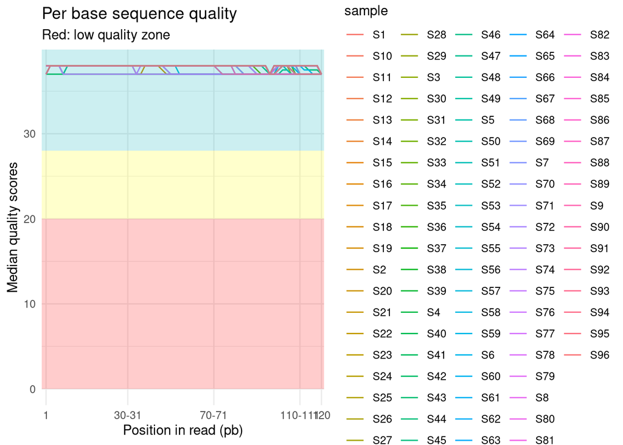

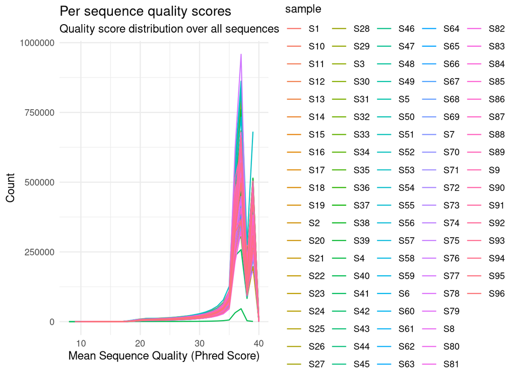

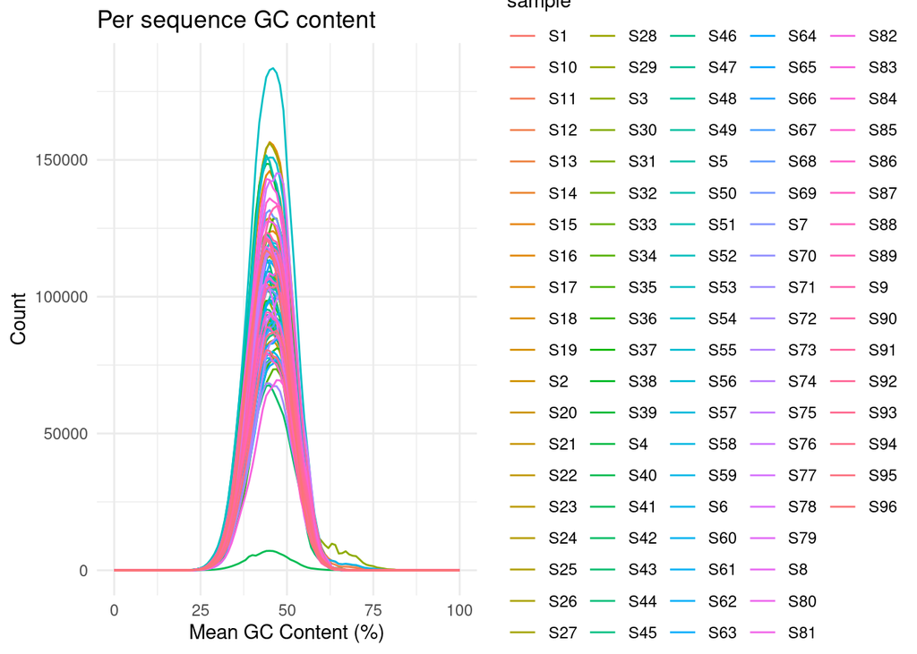

```r
library(fastqcr)
fqs_path <- readLines("crepi_path.txt")

if (! file.exists("reports")){
   for (i in 1:length(fqs_path)) {
      fastqc(fq.dir = fqs_path[i], qc.dir = "reports",
         threads = 16, fastqc.path = "/usr/local/bin/fastqc")
   }
}

qc.files <- list.files(path = "reports", all.files = FALSE,
                      full.names = TRUE, pattern = "zip")
nb_samples <- length(qc.files)

# read specific modules in all files
# To read all modules, specify: modules = "all"
modules <- c(
  "Per sequence GC content",
  "Per base sequence quality",
  "Per sequence quality scores"
)
if (file.exists('qc.rds')) {
   qc <- readRDS('qc.rds')
} else {
   qc <- qc_read_collection(qc.files, sample_names = paste('S', 1:nb_samples, sep = ''),
         modules = "all", verbose = FALSE)
   saveRDS(qc, 'qc.rds')
}
qc_plot_collection(qc, modules = modules)
```

### Demultiplexing results

Every `PAR2no*_fastqs` folder, resulting from the demultiplexing of every sub-library, contains an `s1_demultiplex_stats.txt` file, with three sections, separated by blank lines. The first section shows the number of reads processed from each `fastq.gz` file demultiplexed with the same set of barcodes. The second section shows the number of reads assigned to each sample from those files. The third section also shows the number of reads assigned to samples, and includes the searched and the observed codeword corresponding to each sample. It also shows the number of reads not assigned to any sample. Note that in the third section (but not in the second) the name of the sample may be supplemented with the suffix *technical-replicate-0* if any sample in the barcode got assigned more than one codeword. That happens in libraries PAR2no4, PAR2no5 and PAR2no6 only.

Because there are 16 such files, below I gather each section from all them in a separate file.

```bash
if [ ! -e demultiplex_summary3.txt ]; then
   # When record separator (RS) of awk is set to null, it separates by blank lines.
   find . -name s1_demultiplex_stats.txt | \
   xargs gawk -v RS= '{print >> ("z" FNR ".txt")}'
   grep -v "^raw_file"    z1.txt | sort > demultiplex_summary1.txt
   grep -v "^sample_name" z2.txt | sort > demultiplex_summary2.txt
   grep -v "^sample_name" z3.txt | sort > demultiplex_summary3.txt
   rm z1.txt z2.txt z3.txt
fi
```

Note that the demultiplexing retrieved FASTQ files for samples that are not of interest here, but were sequenced together.

```r
library(ggplot2)
library(kableExtra)
dem1 <- read.table('demultiplex_summary1.txt',
                   col.names = c('raw_file', 'total_reads', 'cut_found', 'bar_matched'))
dem1$no_match <- dem1$total_reads - dem1$bar_matched
dem1$no_match_prop <- dem1$no_match / dem1$total_reads
dem1 <- dem1[order(dem1$total_reads, decreasing = TRUE), ]
dem1$barcode_file <- sapply(strsplit(dem1$raw_file, '_'), '[[', 1)
dem1$library      <- sapply(strsplit(dem1$raw_file, '_'), '[[', 2)
dem1$sense        <- sapply(strsplit(dem1$raw_file, '_'), '[[', 3)
dem1$seqRun       <- sapply(strsplit(dem1$raw_file, '[_\\.]', perl = TRUE), '[[', 4)
kable(dem1) %>% kable_styling()
```

|  | raw_file | total_reads | cut_found | bar_matched | no_match | no_match_prop | barcode_file | library | sense | seqRun |
| --- | --- | --- | --- | --- | --- | --- | --- | --- | --- | --- |
| 94 | PAR2no9_L8_R1_13.fastq | 17475603 | 17475603 | 16859615 | 615988 | 0.0352485 | PAR2no9 | L8 | R1 | 13 |
| 96 | PAR2no9_L8_R2_13.fastq | 17475603 | 17475603 | 16859615 | 615988 | 0.0352485 | PAR2no9 | L8 | R2 | 13 |
| 88 | PAR2no8_L8_R1_13.fastq | 16826840 | 16826840 | 16194044 | 632796 | 0.0376063 | PAR2no8 | L8 | R1 | 13 |
| 90 | PAR2no8_L8_R2_13.fastq | 16826840 | 16826840 | 16194044 | 632796 | 0.0376063 | PAR2no8 | L8 | R2 | 13 |
| 13 | PAR2no12_L2_R1_41.fastq | 16459852 | 16459852 | 13509093 | 2950759 | 0.1792701 | PAR2no12 | L2 | R1 | 41 |
| 14 | PAR2no12_L2_R2_41.fastq | 16459852 | 16459852 | 13509093 | 2950759 | 0.1792701 | PAR2no12 | L2 | R2 | 41 |
| 46 | PAR2no1_L8_R1_13.fastq | 16219449 | 16219449 | 15611155 | 608294 | 0.0375040 | PAR2no1 | L8 | R1 | 13 |
| 48 | PAR2no1_L8_R2_13.fastq | 16219449 | 16219449 | 15611155 | 608294 | 0.0375040 | PAR2no1 | L8 | R2 | 13 |
| 4 | PAR2no10_L8_R1_13.fastq | 15491381 | 15491381 | 14744782 | 746599 | 0.0481945 | PAR2no10 | L8 | R1 | 13 |
| 6 | PAR2no10_L8_R2_13.fastq | 15491381 | 15491381 | 14744782 | 746599 | 0.0481945 | PAR2no10 | L8 | R2 | 13 |
| 93 | PAR2no9_L8_R1_11.fastq | 15183755 | 15183755 | 14719657 | 464098 | 0.0305654 | PAR2no9 | L8 | R1 | 11 |
| 95 | PAR2no9_L8_R2_11.fastq | 15183755 | 15183755 | 14719657 | 464098 | 0.0305654 | PAR2no9 | L8 | R2 | 11 |
| 82 | PAR2no7_L8_R1_13.fastq | 15157811 | 15157811 | 14607341 | 550470 | 0.0363159 | PAR2no7 | L8 | R1 | 13 |
| 84 | PAR2no7_L8_R2_13.fastq | 15157811 | 15157811 | 14607341 | 550470 | 0.0363159 | PAR2no7 | L8 | R2 | 13 |
| 91 | PAR2no9_L2_R1_41.fastq | 15109051 | 15109051 | 12543255 | 2565796 | 0.1698185 | PAR2no9 | L2 | R1 | 41 |
| 92 | PAR2no9_L2_R2_41.fastq | 15109051 | 15109051 | 12543255 | 2565796 | 0.1698185 | PAR2no9 | L2 | R2 | 41 |
| 7 | PAR2no11_L2_R1_41.fastq | 15090182 | 15090182 | 12317351 | 2772831 | 0.1837507 | PAR2no11 | L2 | R1 | 41 |
| 8 | PAR2no11_L2_R2_41.fastq | 15090182 | 15090182 | 12317351 | 2772831 | 0.1837507 | PAR2no11 | L2 | R2 | 41 |
| 87 | PAR2no8_L8_R1_11.fastq | 14715885 | 14715885 | 14232199 | 483686 | 0.0328683 | PAR2no8 | L8 | R1 | 11 |
| 89 | PAR2no8_L8_R2_11.fastq | 14715885 | 14715885 | 14232199 | 483686 | 0.0328683 | PAR2no8 | L8 | R2 | 11 |
| 79 | PAR2no7_L2_R1_41.fastq | 14658318 | 14658318 | 12206035 | 2452283 | 0.1672963 | PAR2no7 | L2 | R1 | 41 |
| 80 | PAR2no7_L2_R2_41.fastq | 14658318 | 14658318 | 12206035 | 2452283 | 0.1672963 | PAR2no7 | L2 | R2 | 41 |
| 10 | PAR2no11_L8_R1_13.fastq | 14269623 | 14269623 | 13730744 | 538879 | 0.0377641 | PAR2no11 | L8 | R1 | 13 |
| 12 | PAR2no11_L8_R2_13.fastq | 14269623 | 14269623 | 13730744 | 538879 | 0.0377641 | PAR2no11 | L8 | R2 | 13 |
| 45 | PAR2no1_L8_R1_11.fastq | 14156028 | 14156028 | 13691669 | 464359 | 0.0328029 | PAR2no1 | L8 | R1 | 11 |
| 47 | PAR2no1_L8_R2_11.fastq | 14156028 | 14156028 | 13691669 | 464359 | 0.0328029 | PAR2no1 | L8 | R2 | 11 |
| 40 | PAR2no16_L8_R1_13.fastq | 14024731 | 14024731 | 13530267 | 494464 | 0.0352566 | PAR2no16 | L8 | R1 | 13 |
| 42 | PAR2no16_L8_R2_13.fastq | 14024731 | 14024731 | 13530267 | 494464 | 0.0352566 | PAR2no16 | L8 | R2 | 13 |
| 64 | PAR2no4_L8_R1_13.fastq | 13988826 | 13988826 | 13445681 | 543145 | 0.0388271 | PAR2no4 | L8 | R1 | 13 |
| 66 | PAR2no4_L8_R2_13.fastq | 13988826 | 13988826 | 13445681 | 543145 | 0.0388271 | PAR2no4 | L8 | R2 | 13 |

[output cut: 66 more lines]

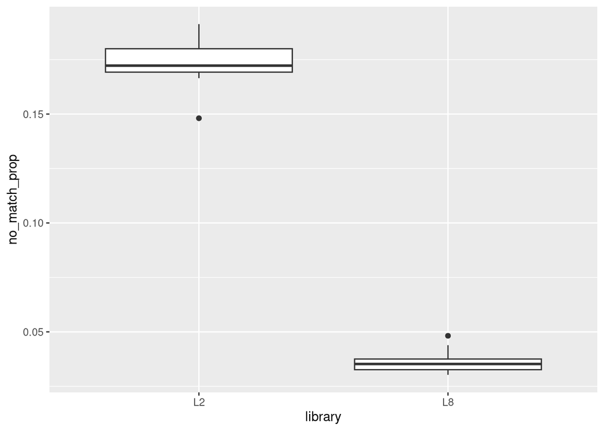

```r
ggplot(dem1, aes(x = library, y = no_match_prop)) + geom_boxplot()
```

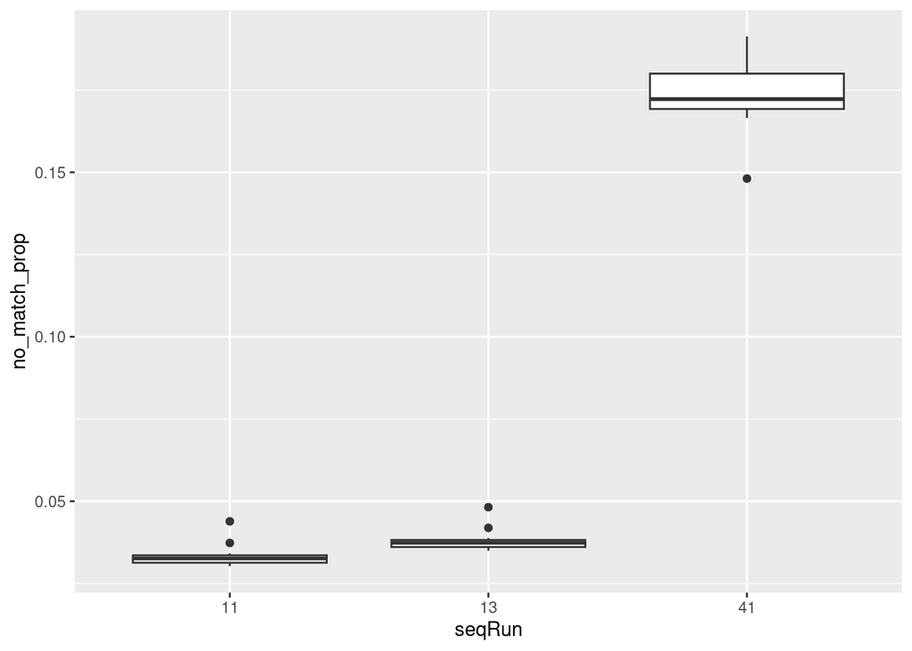

```r
ggplot(dem1, aes(x = seqRun,  y = no_match_prop)) + geom_boxplot()
```

I think PAR1, PAR2 and PAR3 corresponded to three sequencing runs, while L2 and L8 are the actual libraries. If so, library L2 got sequenced in one run (*41*), while library L8 got sequenced in two runs, *11* and *13*. For some reason (higher error rates?) the fraction of reads not assigned to any sample is higher in sequencing run *41*.

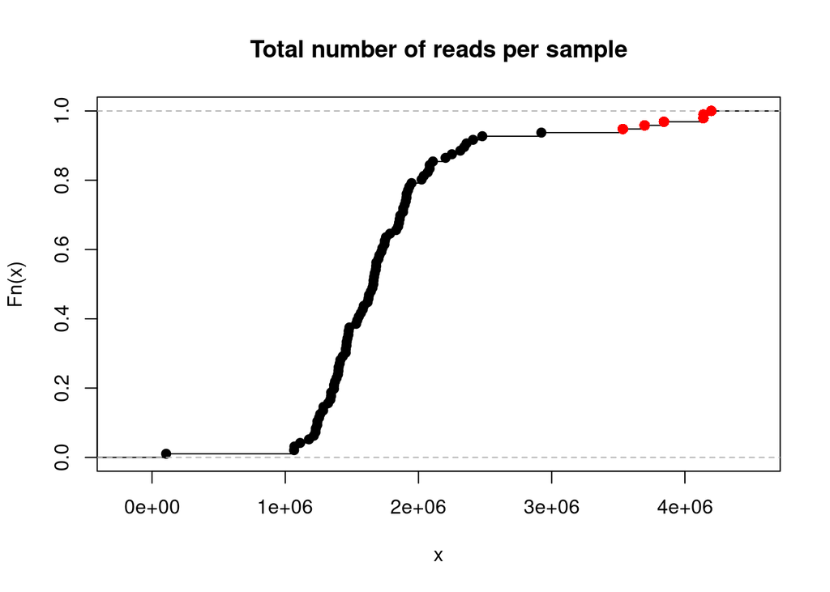

```r
library(dplyr)
dem2 <- read.table('demultiplex_summary2.txt',
                   col.names = c('sample_name', 'total_reads'))
# only Crepidostomum:
samples <- scan('samples.txt', what = 'character', quiet = TRUE)
dem2 <- dem2[dem2$sample_name %in% samples,]

# join reads of the same sample
dem2v <- group_by(dem2, sample_name) %>%
   summarise(total_reads = sum(total_reads),
             multiplicity = n())
dem2v <- as.data.frame(dem2v) # I hate tibbles

plot(ecdf(dem2v$total_reads),
     main = 'Total number of reads per sample')
points(dem2v[dem2v$multiplicity > 1, 'total_reads'],
       ecdf(dem2v$total_reads)(dem2v[dem2v$multiplicity > 1, 'total_reads']),
       col = 'red', pch = 16, cex = 1.2)
```

According to the barcodes, a few samples were sequenced twice, with different barcodes each time. They are painted red in the previous plot to show that they got about twice as many reads as the rest, as expected. Only one sample got much fewer than 1 milion reads, namely: N044Cx2

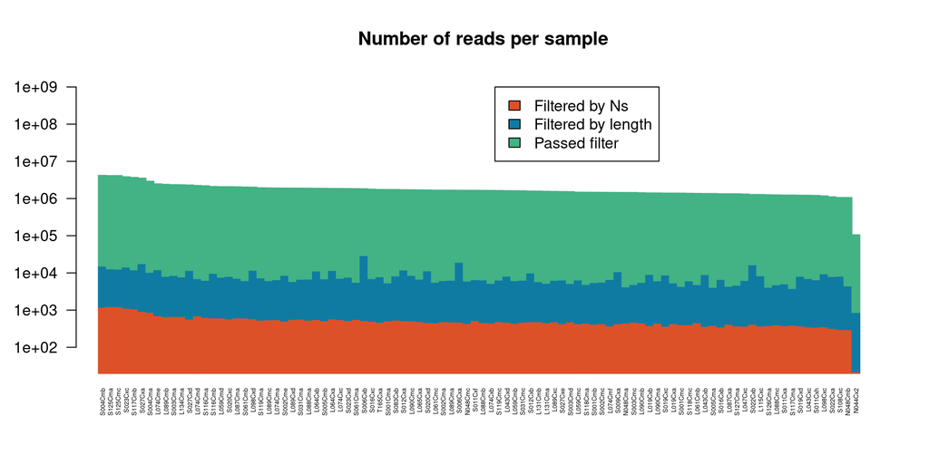

```r
library('MetBrewer')
edits <- read.table('crepi_edits/s2_rawedit_stats.txt')
plot(c(1, dim(edits)[1]), c(50, 1e+09), type = 'n', xlab = '', ylab = '',
     axes = FALSE, log = 'y', main = 'Number of reads per sample')
barplot(t(edits[order(edits$reads_raw, decreasing = TRUE), 6:8]),
        col = met.brewer('Egypt', 3), border = met.brewer('Egypt', 3),
        las = 2, cex.names = 0.4, add = TRUE, log = 'y', space = 0)
legend(50, 1.0e+09, legend = c('Filtered by Ns', 'Filtered by length', 'Passed filter'),
       fill = met.brewer('Egypt', 3))
```

Note the logarithmic scale in the plot above. Actually, the vast majority of reads passed the filter. Plot in this way, we can see better that filters acted proportionally on every sample.